**Mercari Price Suggestion Challenge**

# 1. Business Problem

## 1.1. Description

Source: https://www.kaggle.com/c/mercari-price-suggestion-challenge

Data: Mercari: The Selling App, Japan.

Download train.tsv.7z and test.tsv.7z from Kaggle.

*Context* :

Source: https://www.kaggle.com/c/mercari-price-suggestion-challenge/discussion/50250

*Problem Statement* :

To build an algorithm that automatically suggests the right product prices given the user-inputted text descriptions of the products.

## 1.2. Source/Useful Links

## 1.3. Real-world/Business objectives and constraints.

- Low latency requirement.
- Errors can be costly.
- Interpretability is important.
- Probability of Price suggestion for a product can be useful.
- Price suggestion range can be useful.

# 2. Machine Learning Problem Formulation

## 2.1. Data

### 2.1.1. Data Overview

- *train_id or test_id :* the id of the listing or product.
- *name :* the title of the listing or product.
- *item_condition_id :* the condition of the items provided by the seller.
- *category_name :* category of the listing or product.
- *brand_name :* brand name of the product or listing.
- *price :* the price that the item was sold for. This is the target variable that should be predicted. The unit is USD. This column doesn't exist in test.tsv since that is what you I have to predict.
- *shipping :* 1 if shipping fee is paid by seller and 0 by buyer
- *item_description :* the full description of the item.

  **Note**: The data has been cleaned to remove text that look like prices (e.g. $20) to avoid leakage. These removed prices are represented as [rm]

### 2.1.2. Example Data Point

## 2.2. Mapping the real-world problem to an ML problem

### 2.2.1. Type of Machine Learning Problem

- Learn the pricing of existing products and predict the pricing of future products. It is a Regression Problem.

### 2.2.2. Performance Metric

Source: https://www.kaggle.com/c/mercari-price-suggestion-challenge#evaluation

The evaluation metric is **Root Mean Squared Logarithmic Error(RMSLE)**.

The RMSLE is calculated as

$$\epsilon = \sqrt{\frac{1}{n} \sum_{i=1}^n (\log(p_i + 1) - \log(a_i+1))^2 }$$

Where:

- $\epsilon$ is the RMSLE value (score),
- n is the total number of observations in the (public/private) data set,
- p_i is your prediction of price,
- a_i is the actual sale price for i,
- $\log(x)$ is the natural logarithm of x.

### 2.2.3. Machine Learing Objectives and Constraints

**Objective:** Predict the pricing of the products.

**Constraints:**

- Low latency requirement.
- Interpretability.
- Price range of products with confidence intervals.

## 2.3. Train and Test Datasets

- Train and Test datasets have been given.
- Test data is given in two stages. Smaller test dataset in the first stage and larger test dataset in the second stage.

# 3. Exploratory Data Analysis

```python
# This Python 3 environment comes with many helpful analytics libraries installed
# It is defined by the kaggle/python docker image: https://github.com/kaggle/docker-python
# For example, here's several helpful packages to load in

import numpy as np # linear algebra
import pandas as pd # data processing, CSV file I/O (e.g. pd.read_csv)

# Input data files are available in the "../input/" directory.
# For example, running this (by clicking run or pressing Shift+Enter) will list the files in the input directory

import os
print(os.listdir("../input"))

# Any results you write to the current directory are saved as output.
```

```
['train.tsv', 'test.tsv']
```

```python
import re
import nltk
import string
import numpy as np
import pandas as pd
import seaborn as sns
import matplotlib.pyplot as plt


from nltk.stem.porter import *
from nltk.corpus import stopwords
from sklearn.feature_extraction import stop_words
from nltk.tokenize import word_tokenize, sent_tokenize



from collections import Counter
from wordcloud import WordCloud
from sklearn.feature_extraction.text import TfidfVectorizer
from sklearn.feature_extraction.text import CountVectorizer


import plotly.offline as py
py.init_notebook_mode(connected=True)
import plotly.graph_objs as go
import plotly.tools as tls
%matplotlib inline


import warnings
warnings.filterwarnings('ignore')
```

## 3.1. Reading Data

```python
train = pd.read_csv('../input/train.tsv', sep='\t')
test = pd.read_csv('../input/test.tsv', sep='\t')
```

```python
# dimensions and features of training dataset
print('\nNumber of data points in training dataset : ', train.shape[0])
print('\nNumber of features in training dataset    : ', train.shape[1])
print('\nTraning Features : ', train.columns.values)

print('\n*************************************************************************\n')

# dimensions and features of test dataset
print('\nNumber of data points in test dataset : ', test.shape[0])
print('\nNumber of features in test dataset    : ', test.shape[1])
print('\nTest Features : \n', test.columns.values)

print('\n*************************************************************************')
print('\nSample training data\n---------------------')
train.head()
```

```
Number of data points in training dataset :  1482535

Number of features in training dataset    :  8

Traning Features :  ['train_id' 'name' 'item_condition_id' 'category_name' 'brand_name' 'price'
 'shipping' 'item_description']



Number of data points in test dataset :  693359

Number of features in test dataset    :  7

Test Features :
 ['test_id' 'name' 'item_condition_id' 'category_name' 'brand_name'
 'shipping' 'item_description']


Sample training data
---------------------
```

|  | train_id | name | item_condition_id | category_name | brand_name | price | shipping | item_description |
| --- | --- | --- | --- | --- | --- | --- | --- | --- |
| 0 | 0 | MLB Cincinnati Reds T Shirt Size XL | 3 | Men/Tops/T-shirts | NaN | 10.0 | 1 | No description yet |
| 1 | 1 | Razer BlackWidow Chroma Keyboard | 3 | Electronics/Computers & Tablets/Components & P... | Razer | 52.0 | 0 | This keyboard is in great condition and works ... |
| 2 | 2 | AVA-VIV Blouse | 1 | Women/Tops & Blouses/Blouse | Target | 10.0 | 1 | Adorable top with a hint of lace and a key hol... |
| 3 | 3 | Leather Horse Statues | 1 | Home/Home Décor/Home Décor Accents | NaN | 35.0 | 1 | New with tags. Leather horses. Retail for [rm]... |
| 4 | 4 | 24K GOLD plated rose | 1 | Women/Jewelry/Necklaces | NaN | 44.0 | 0 | Complete with certificate of authenticity |

```python
# different data types in the dataset: categorical (strings) and numeric
train.dtypes
```

```
train_id               int64
name                  object
item_condition_id      int64
category_name         object
brand_name            object
price                float64
shipping               int64
item_description      object
dtype: object
```

## Price

```python
train.price.head()
```

```
0    10.0
1    52.0
2    10.0
3    35.0
4    44.0
Name: price, dtype: float64
```

```python
train.price.describe()
```

```
count    1.482535e+06
mean     2.673752e+01
std      3.858607e+01
min      0.000000e+00
25%      1.000000e+01
50%      1.700000e+01
75%      2.900000e+01
max      2.009000e+03
Name: price, dtype: float64
```

```python
train.price.isnull().values.any()
```

```
False
```

- There are no NaN's in the price column.

```python
train.name.loc[train['price']==0]
```

```
1325           Alabama Crimson Tide Quality Lanyard
2544                                  Levi leggings
2712                   Simple Red Lace Lingerie Top
3576               Turquoise 15 Pc Makeup Brush Set
3761                                 Girls size 7/8
5237                                    Nursing Bra
6175          Multi Listing Bundled Package, Thanks
7116           Nike Dri-Fit High Power Speed Tights
7622                            Hands free earpiece
10812                            Vampire candy bowl
12738         Beautiful Janie and Jack loafers sz 4
17617                       Coca Cola Stuffed Bears
17831                        Holographic sequin bra
18324              Pura 11 oz straw cup, swirl pink
19909                      Obey Floral Snapback Hat
```

[output cut: 47 more lines]

```python
train.name.loc[train.price == 0].count()
```

```
874
```

```python
train = train[train['price' ]> 0]
```

```python
train.shape
```

```
(1481661, 8)
```

```python
train.price.head()
```

```
0    10.0
1    52.0
2    10.0
3    35.0
4    44.0
Name: price, dtype: float64
```

```python
train.name.loc[train.price == 0].count()
```

```
0
```

- 874 products have price 0. Those products might be given free for some other products.
- Those products with zero price occur in duplicates with varied prices.
- All the products whose price is zero are removed from training data.

```python
(train.price == 0).sum()
```

```
0
```

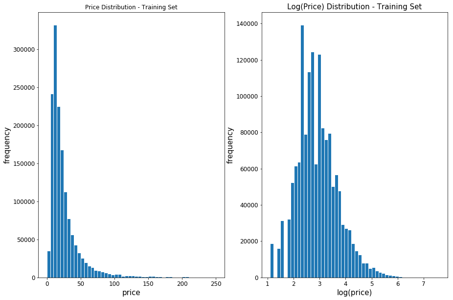

```python
plt.subplot(1, 2, 1)
train['price'].plot.hist(bins=50, figsize=(15,10), edgecolor='white',range=[0,250])
plt.xlabel('price', fontsize=15)
plt.ylabel('frequency', fontsize=15)
plt.tick_params(labelsize=12)
plt.title('Price Distribution - Training Set', fontsize=12)

plt.subplot(1, 2, 2)
np.log(train['price']).plot.hist(bins=50, figsize=(15,10), edgecolor='white')
plt.xlabel('log(price)', fontsize=15)
plt.ylabel('frequency', fontsize=15)
plt.tick_params(labelsize=12)
plt.title('Log(Price) Distribution - Training Set', fontsize=15)
plt.show()
```

```python
train.price.describe()
```

```
count    1.481661e+06
mean     2.675329e+01
std      3.859198e+01
min      3.000000e+00
25%      1.000000e+01
50%      1.700000e+01
75%      2.900000e+01
max      2.009000e+03
Name: price, dtype: float64
```

- The mean price of the products is 26.75 USD
- Median proce of products is 17
- Min price is 3 USD
- Max price is 2009 USD

**Observations:**

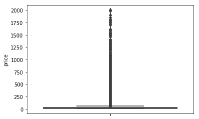

```python
sns.boxplot(y=train.price)
plt.show()
```

## Shipping

```python
train.shipping.value_counts()
```

```
0    818876
1    662785
Name: shipping, dtype: int64
```

- Shipping is a categorical feature.
- **0 ------> Shipping fee paid by Buyer.**
- **1 ------> Shipping fee paid by Seller.**
- For 818876 products shipping fee is paid by buyer.
- For 662785 products shipping fee is paid by seller.

```python
train.shipping.value_counts()/len(train)
```

```
0    0.552674
1    0.447326
Name: shipping, dtype: float64
```

```python
x,y = train.shipping.value_counts()/len(train)
print('Shipping fee of {0:.2f}% of the products is paid by Buyer'.format(x*100))
print('Shipping fee of {0:.2f}% of the products is paid by Seller'.format(y*100))
```

```
Shipping fee of 55.27% of the products is paid by Buyer
Shipping fee of 44.73% of the products is paid by Seller
```

```python
# freeShipping ----> Shipping fee paid by Seller
freeShipping = train.loc[train.shipping==1, 'price']
# paidShipping -----> Shipping fee paid by Buyer
paidShipping = train.loc[train.shipping==0, 'price']
```

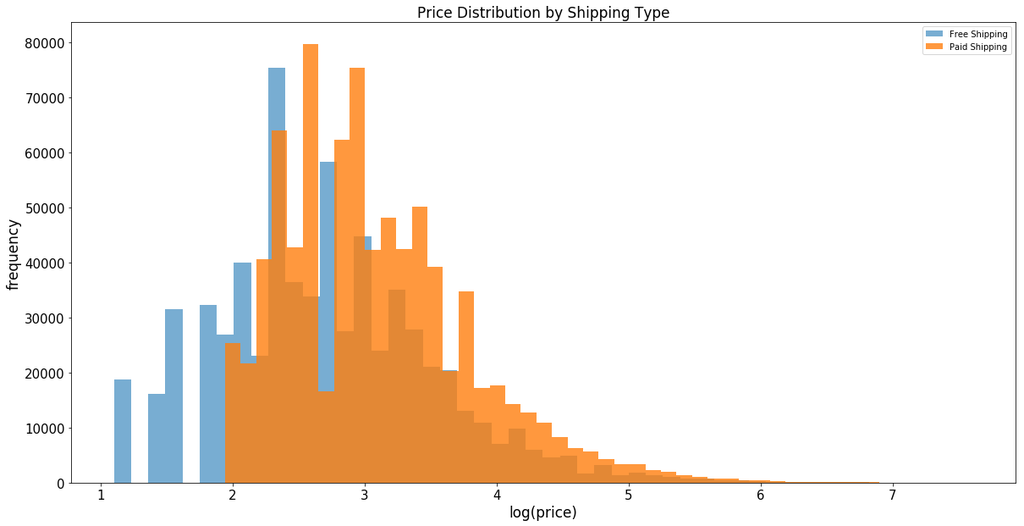

```python
# plotting Price distribution with respect to shipping type

fig, ax = plt.subplots(figsize=(20,10))
ax.hist(np.log(freeShipping),  alpha=0.6, bins=50,label='Free Shipping')
ax.hist(np.log(paidShipping), alpha=0.8, bins=50,label='Paid Shipping')
ax.set(title='Histogram Comparison', ylabel='% of Dataset in Bin')
plt.xlabel('log(price)', fontsize=17)
plt.ylabel('frequency', fontsize=17)
plt.title('Price Distribution by Shipping Type', fontsize=17)
handles, labels = ax.get_legend_handles_labels()
ax.legend(handles, labels)
plt.tick_params(labelsize=15)
plt.show()
```

```python
print('Average price of products with free shipping is %.2f'%freeShipping.mean())
print('Average price of products with paid shipping is %.2f'%paidShipping.mean())
```

```
Average price of products with free shipping is 22.58
Average price of products with paid shipping is 30.13
```

- **As mean is prone to outliers, let's check median of shipping types.**

```python
print('Median price of products with free shipping is %.2f'%freeShipping.median())
print('Median price of products with paid shipping is %.2f'%paidShipping.median())
```

```
Median price of products with free shipping is 14.00
Median price of products with paid shipping is 20.00
```

**Observations:**

- Generally we might think that, price of the product is somehow correlated with shipping fee.
- If shipping is free, price of the product might be high.
- If shipping is paid,price of the product might be less.
- It is evident from the above graph that **this is not the scenario in this case**.
- **Average price of products is lesser in case of free shipping.** -**Average price of product is higher in case of paid shipping.**

```python
train.price.head()
```

```
0    10.0
1    52.0
2    10.0
3    35.0
4    44.0
Name: price, dtype: float64
```

```python
print(paidShipping.describe())
print(freeShipping.describe())
```

```
count    818876.000000
mean         30.132333
std          39.541581
min           5.500000
25%          13.000000
50%          20.000000
75%          33.000000
max        2009.000000
Name: price, dtype: float64
count    662785.000000
mean         22.578452
std          36.961295
min           3.000000
25%           9.000000
50%          14.000000
75%          25.000000
max        2000.000000
Name: price, dtype: float64
```

## Item Category

```python
print("There are %d unique values in the category column." % train['category_name'].nunique())
```

```
There are 1287 unique values in the category column.
```

```python
# TOP 5 RAW CATEGORIES
train['category_name'].value_counts()[:5]
```

```
Women/Athletic Apparel/Pants, Tights, Leggings    60152
Women/Tops & Blouses/T-Shirts                     46349
Beauty/Makeup/Face                                34320
Beauty/Makeup/Lips                                29901
Electronics/Video Games & Consoles/Games          26547
Name: category_name, dtype: int64
```

```python
# missing categories
print("There are %d items that do not have a label." % train['category_name'].isnull().sum())
```

```
There are 6314 items that do not have a label.
```

```python
# reference: BuryBuryZymon at https://www.kaggle.com/maheshdadhich/i-will-sell-everything-for-free-0-55
def split_cat(text):
    try: return text.split("/")
    except: return ("No Label", "No Label", "No Label")
```

```python
# splitting the raw category into main and sub sub categories
train['main_cat'], train['subcat_1'], train['subcat_2'] = \
zip(*train['category_name'].apply(lambda x: split_cat(x)))
# sanity checking the train for new categories
train.head()
```

|  | train_id | name | item_condition_id | category_name | brand_name | price | shipping | item_description | main_cat | subcat_1 | subcat_2 |
| --- | --- | --- | --- | --- | --- | --- | --- | --- | --- | --- | --- |
| 0 | 0 | MLB Cincinnati Reds T Shirt Size XL | 3 | Men/Tops/T-shirts | NaN | 10.0 | 1 | No description yet | Men | Tops | T-shirts |
| 1 | 1 | Razer BlackWidow Chroma Keyboard | 3 | Electronics/Computers & Tablets/Components & P... | Razer | 52.0 | 0 | This keyboard is in great condition and works ... | Electronics | Computers & Tablets | Components & Parts |
| 2 | 2 | AVA-VIV Blouse | 1 | Women/Tops & Blouses/Blouse | Target | 10.0 | 1 | Adorable top with a hint of lace and a key hol... | Women | Tops & Blouses | Blouse |
| 3 | 3 | Leather Horse Statues | 1 | Home/Home Décor/Home Décor Accents | NaN | 35.0 | 1 | New with tags. Leather horses. Retail for [rm]... | Home | Home Décor | Home Décor Accents |
| 4 | 4 | 24K GOLD plated rose | 1 | Women/Jewelry/Necklaces | NaN | 44.0 | 0 | Complete with certificate of authenticity | Women | Jewelry | Necklaces |

```python
# repeat the same step for the test set
test['general_cat'], test['subcat_1'], test['subcat_2'] = \
zip(*test['category_name'].apply(lambda x: split_cat(x)))
```

[output not shown]

```python
print("There are %d unique main categories." % train['main_cat'].nunique())
print("There are %d unique first sub-categories." % train['subcat_1'].nunique())
print("There are %d unique second sub-categories." % train['subcat_2'].nunique())
```

```
There are 11 unique main categories.
There are 114 unique first sub-categories.
There are 871 unique second sub-categories.
```

Overall, we have **11 main categories** (114 in the first sub-categories and 871 second sub-categories): women's and beauty items as the two most popular categories (more than 50% of the observations), followed by kids and electronics.

```python
print("There are %d unique first sub-categories." % train['subcat_1'].nunique())
```

[output not shown]

```python
print("There are %d unique second sub-categories." % train['subcat_2'].nunique())
```

[output not shown]

```python
x = train['main_cat'].value_counts().index.values.astype('str')
y = train['main_cat'].value_counts().values
pct = [("%.2f"%(v*100))+"%"for v in (y/len(train))]
```

[output not shown]

```python
trace1 = go.Bar(x=x, y=y, text=pct,
               marker=dict(
                color = y,colorscale='Portland',showscale=True,
                reversescale = False
                ))
layout = dict(title= 'Number of Items by Main Category',
              yaxis = dict(title='Count'),
              xaxis = dict(title='Category'))
fig=dict(data=[trace1], layout=layout)
py.iplot(fig)
```

[interactive chart not shown]

**Observations from Main Category:**

- Women's category is the most popular category constitutes 44.81% of total items followed by Beauty, 14.02% of total items.

```python
x = train['subcat_1'].value_counts().index.values.astype('str')[:15]
y = train['subcat_1'].value_counts().values[:15]
pct = [("%.2f"%(v*100))+"%"for v in (y/len(train))][:15]
```

```python
trace1 = go.Bar(x=x, y=y, text=pct,
                marker=dict(
                color = y,colorscale='Portland',showscale=True,
                reversescale = False
                ))
layout = dict(title= 'Number of Items by Sub Category (Top 15)',
              yaxis = dict(title='Count'),
              xaxis = dict(title='SubCategory'))
fig=dict(data=[trace1], layout=layout)
py.iplot(fig)
```

[interactive chart not shown]

**Observation from Sub Category 1:**

- Athletic Apparel is the most popular category with 9.07% followed by Makeup with 8.41%

```python
main_cats = train['main_cat'].unique()
x = [train.loc[train['main_cat']==cat, 'price'] for cat in main_cats]
```

```python
data = [go.Box(x=np.log(x[i]+1), name=main_cats[i]) for i in range(len(main_cats))]
```

```python
layout = dict(title="Price Distribution by Main Category",
              yaxis = dict(title='Frequency'),
              xaxis = dict(title='Category'))
fig = dict(data=data, layout=layout)
py.iplot(fig)
```

[output not shown]

## Brand Name

- Brand Name is a categorical feature.

```python
print("There are %d unique brand names in the training dataset." % train['brand_name'].nunique())
```

```
There are 4807 unique brand names in the training dataset.
```

```python
x = train['brand_name'].value_counts().index.values.astype('str')[:10]
y = train['brand_name'].value_counts().values[:10]
```

```python
trace1 = go.Bar(x=x, y=y,
                 marker=dict(
                 color = y,colorscale='Portland',showscale=True,
                 reversescale = False
                 ))
layout = dict(title= 'Top 10 Brand by Number of Items',
               yaxis = dict(title='Brand Name'),
               xaxis = dict(title='Count'))
fig=dict(data=[trace1], layout=layout)
py.iplot(fig)
```

[interactive chart not shown]

## Item Description

```python
def wordCount(text):
    # convert to lower case and strip regex
    try:
         # convert to lower case and strip regex
        text = text.lower()
        regex = re.compile('[' +re.escape(string.punctuation) + '0-9\\r\\t\\n]')
        txt = regex.sub(" ", text)
        # tokenize
        # words = nltk.word_tokenize(clean_txt)
        # remove words in stop words
        words = [w for w in txt.split(" ") \
                 if not w in stop_words.ENGLISH_STOP_WORDS and len(w)>3]
        return len(words)
    except:
        return 0
```

```python
# add a column of word counts to both the training and test set
train['desc_len'] = train['item_description'].apply(lambda x: wordCount(x))
test['desc_len'] = test['item_description'].apply(lambda x: wordCount(x))
```

```python
train.head()
```

|  | train_id | name | item_condition_id | category_name | brand_name | price | shipping | item_description | main_cat | subcat_1 | subcat_2 | desc_len |
| --- | --- | --- | --- | --- | --- | --- | --- | --- | --- | --- | --- | --- |
| 0 | 0 | MLB Cincinnati Reds T Shirt Size XL | 3 | Men/Tops/T-shirts | NaN | 10.0 | 1 | No description yet | Men | Tops | T-shirts | 1 |
| 1 | 1 | Razer BlackWidow Chroma Keyboard | 3 | Electronics/Computers & Tablets/Components & P... | Razer | 52.0 | 0 | This keyboard is in great condition and works ... | Electronics | Computers & Tablets | Components & Parts | 14 |
| 2 | 2 | AVA-VIV Blouse | 1 | Women/Tops & Blouses/Blouse | Target | 10.0 | 1 | Adorable top with a hint of lace and a key hol... | Women | Tops & Blouses | Blouse | 8 |
| 3 | 3 | Leather Horse Statues | 1 | Home/Home Décor/Home Décor Accents | NaN | 35.0 | 1 | New with tags. Leather horses. Retail for [rm]... | Home | Home Décor | Home Décor Accents | 14 |
| 4 | 4 | 24K GOLD plated rose | 1 | Women/Jewelry/Necklaces | NaN | 44.0 | 0 | Complete with certificate of authenticity | Women | Jewelry | Necklaces | 3 |

```python
# mean price of unique description lengths
df = train.groupby('desc_len')['price'].mean().reset_index()
```

```python
trace1 = go.Scatter(
    x = df['desc_len'],
    y = np.log(df['price']+1),
    mode = 'lines+markers',
    name = 'lines+markers'
)
layout = dict(title= 'Average Log(Price) by Description Length',
              yaxis = dict(title='Average Log(Price)'),
              xaxis = dict(title='Description Length'))
fig=dict(data=[trace1], layout=layout)
py.iplot(fig)
```

[interactive chart not shown]

We also need to check if there are any missing values in the item description (4 observations don't have a description) andl remove those observations from our training set.

```python
train.item_description.isnull().sum()
```

```
4
```

```python
# remove missing values in item description
train = train[pd.notnull(train['item_description'])]
```

# Item Description

*The following section is based on the tutorial at https://ahmedbesbes.com/how-to-mine-newsfeed-data-and-extract-interactive-insights-in-python.html*

- Item Description is a text feature.
- Pre-processing has to be done on text featue before we analyze.

```python
stop = set(stopwords.words('english'))
def tokenize(text):
    """
    sent_tokenize(): segment text into sentences
    word_tokenize(): break sentences into words
    """
    try:
        regex = re.compile('[' +re.escape(string.punctuation) + '0-9\\r\\t\\n]')
        text = regex.sub(" ", text) # remove punctuation

        tokens_ = [word_tokenize(s) for s in sent_tokenize(text)]
        tokens = []
        for token_by_sent in tokens_:
            tokens += token_by_sent
        tokens = list(filter(lambda t: t.lower() not in stop, tokens))
        filtered_tokens = [w for w in tokens if re.search('[a-zA-Z]', w)]
        filtered_tokens = [w.lower() for w in filtered_tokens if len(w)>=3]

        return filtered_tokens

    except TypeError as e: print(text,e)
```

```python
# create a dictionary of words for each category
cat_desc = dict()
for cat in main_cats:
    text = " ".join(train.loc[train['main_cat']==cat, 'item_description'].values)
    cat_desc[cat] = tokenize(text)

# flat list of all words combined
flat_lst = [item for sublist in list(cat_desc.values()) for item in sublist]
allWordsCount = Counter(flat_lst)
all_top10 = allWordsCount.most_common(20)
x = [w[0] for w in all_top10]
y = [w[1] for w in all_top10]
```

```python
trace1 = go.Bar(x=x, y=y, text=pct)
layout = dict(title= 'Word Frequency',
              yaxis = dict(title='Count'),
              xaxis = dict(title='Word'))
fig=dict(data=[trace1], layout=layout)
py.iplot(fig)
```

[interactive chart not shown]

**Observations:**

- *size*, *free* and *shipping* are very commonly used by the sellers, probably with the intention to attract customers.
- *Brand names* also played quite an important role - it's one of the most popular in all four categories.

## **Pre-processing**

### **Tokenization**

Most of the time, the first steps of an NLP project is to **"tokenize"** your documents, which main purpose is to normalize our texts. The three fundamental stages will usually include:

- break the descriptions into sentences and then break the sentences into tokens.
- remove punctuation and stop words.
- lowercase the tokens.
- herein, I will also only consider words that have length equal to or greater than 3 characters.

```python
# apply the tokenizer into the item descriptipn column
train['tokens'] = train['item_description'].map(tokenize)
test['tokens'] = test['item_description'].map(tokenize)
```

```python
train.reset_index(drop=True, inplace=True)
test.reset_index(drop=True, inplace=True)
```

Let's look at the examples of if the tokenizer did a good job in cleaning up our descriptions

```python
for description, tokens in zip(train['item_description'].head(),
                              train['tokens'].head()):
    print('description:', description)
    print('tokens:', tokens)
    print()
```

```
description: No description yet
tokens: ['description', 'yet']

description: This keyboard is in great condition and works like it came out of the box. All of the ports are tested and work perfectly. The lights are customizable via the Razer Synapse app on your PC.
tokens: ['keyboard', 'great', 'condition', 'works', 'like', 'came', 'box', 'ports', 'tested', 'work', 'perfectly', 'lights', 'customizable', 'via', 'razer', 'synapse', 'app']

description: Adorable top with a hint of lace and a key hole in the back! The pale pink is a 1X, and I also have a 3X available in white!
tokens: ['adorable', 'top', 'hint', 'lace', 'key', 'hole', 'back', 'pale', 'pink', 'also', 'available', 'white']

description: New with tags. Leather horses. Retail for [rm] each. Stand about a foot high. They are being sold as a pair. Any questions please ask. Free shipping. Just got out of storage
tokens: ['new', 'tags', 'leather', 'horses', 'retail', 'stand', 'foot', 'high', 'sold', 'pair', 'questions', 'please', 'ask', 'free', 'shipping', 'got', 'storage']

description: Complete with certificate of authenticity
tokens: ['complete', 'certificate', 'authenticity']
```

We could aso use the package `WordCloud` to easily visualize which words has the highest frequencies within each category:

```python
# build dictionary with key=category and values as all the descriptions related.
cat_desc = dict()
for cat in main_cats:
    text = " ".join(train.loc[train['main_cat']==cat, 'item_description'].values)
    cat_desc[cat] = tokenize(text)


# find the most common words for the top 4 categories
women100 = Counter(cat_desc['Women']).most_common(100)
beauty100 = Counter(cat_desc['Beauty']).most_common(100)
kids100 = Counter(cat_desc['Kids']).most_common(100)
electronics100 = Counter(cat_desc['Electronics']).most_common(100)
```

```python
def generate_wordcloud(tup):
    wordcloud = WordCloud(background_color='black',
                          max_words=50, max_font_size=30,
                          random_state=36
                         ).generate(str(tup))
    return wordcloud
```

```
Text(0.5,1,'Electronic Top 100')
```

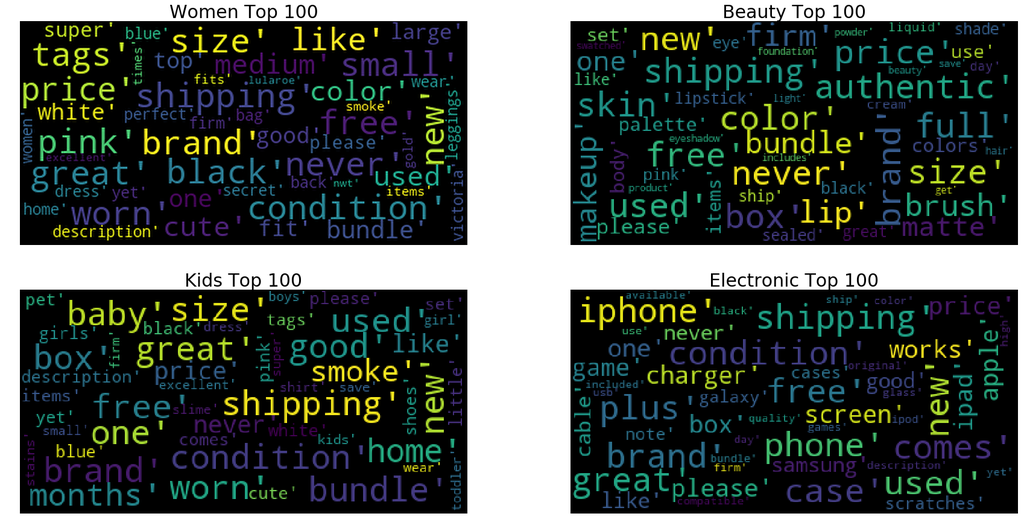

```python
fig,axes = plt.subplots(2, 2, figsize=(30, 15))

ax = axes[0, 0]
ax.imshow(generate_wordcloud(women100), interpolation="sinc")
ax.axis('off')
ax.set_title("Women Top 100", fontsize=30)

ax = axes[0, 1]
ax.imshow(generate_wordcloud(beauty100))
ax.axis('off')
ax.set_title("Beauty Top 100", fontsize=30)

ax = axes[1, 0]
ax.imshow(generate_wordcloud(kids100))
ax.axis('off')
ax.set_title("Kids Top 100", fontsize=30)

ax = axes[1, 1]
ax.imshow(generate_wordcloud(electronics100))
ax.axis('off')
ax.set_title("Electronic Top 100", fontsize=30)
```

```
(-0.5, 1439.5, 1079.5, -0.5)
```

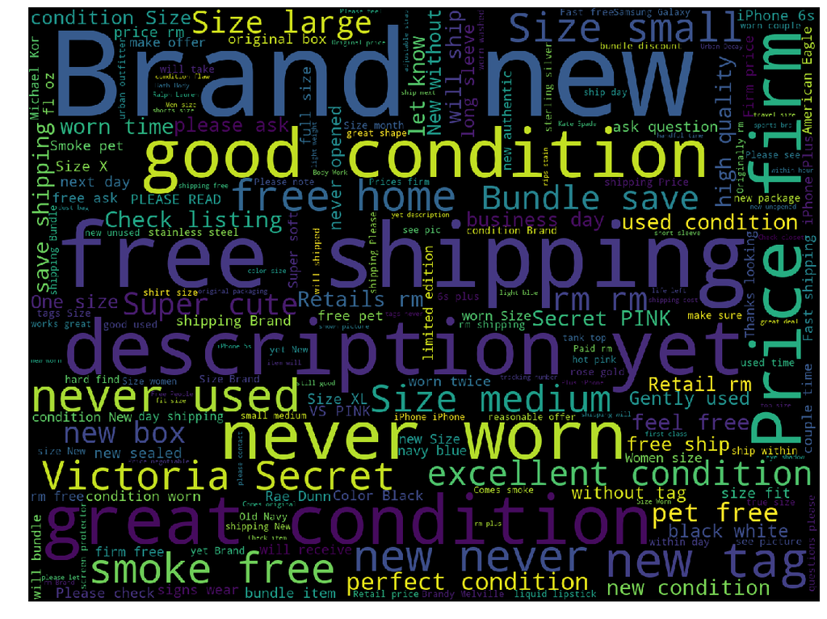

```python
cloud = WordCloud(width=1440, height=1080).generate(" ".join(train['item_description']
.astype(str)))
plt.figure(figsize=(20, 15))
plt.imshow(cloud)
plt.axis('off')
```

## **Pre-processing: tf-idf**

tf-idf is the acronym for **Term Frequency–inverse Document Frequency**. It quantifies the importance of a particular word in relative to the vocabulary of a collection of documents or corpus. The metric depends on two factors:

- **Term Frequency**: the occurences of a word in a given document (i.e. bag of words)
- **Inverse Document Frequency**: the reciprocal number of times a word occurs in a corpus of documents

Think about of it this way: If the word is used extensively in all documents, its existence within a specific document will not be able to provide us much specific information about the document itself. So the second term could be seen as a penalty term that penalizes common words such as "a", "the", "and", etc. tf-idf can therefore, be seen as a weighting scheme for words relevancy in a specific document.

```python
from sklearn.feature_extraction.text import TfidfVectorizer
vectorizer = TfidfVectorizer(min_df=10,
                             max_features=180000,
                             tokenizer=tokenize,
                             ngram_range=(1, 2))
```

```python
all_desc = np.append(train['item_description'].values, test['item_description'].values)
vz = vectorizer.fit_transform(list(all_desc))
```

vz is a tfidf matrix where:

- the number of rows is the total number of descriptions
- the number of columns is the total number of unique tokens across the descriptions

```python
#  create a dictionary mapping the tokens to their tfidf values
tfidf = dict(zip(vectorizer.get_feature_names(), vectorizer.idf_))
tfidf = pd.DataFrame(columns=['tfidf']).from_dict(
                    dict(tfidf), orient='index')
tfidf.columns = ['tfidf']
```

Below is the 10 tokens with the lowest tfidf score, which is unsurprisingly, very generic words that we could not use to distinguish one description from another.

```python
tfidf.sort_values(by=['tfidf'], ascending=True).head(10)
```

[output not shown]

Below is the 10 tokens with the highest tfidf score, which includes words that are a lot specific that by looking at them, we could guess the categories that they belong to:

```python
tfidf.sort_values(by=['tfidf'], ascending=False).head(10)
```

[output not shown]

### **t-Distributed Stochastic Neighbor Embedding (t-SNE)**

t-SNE is a technique for dimensionality reduction that is particularly well suited for the visualization of high-dimensional datasets. The goal is to take a set of points in a high-dimensional space and find a representation of those points in a lower-dimensional space, typically the 2D plane. It is based on probability distributions with random walk on neighborhood graphs to find the structure within the data. But since t-SNE complexity is significantly high, usually we'd use other high-dimension reduction techniques before applying t-SNE.

```python
trn = train.copy()
tst = test.copy()
trn['is_train'] = 1
tst['is_train'] = 0

sample_sz = 15000

combined_df = pd.concat([trn, tst])
combined_sample = combined_df.sample(n=sample_sz)
vz_sample = vectorizer.fit_transform(list(combined_sample['item_description']))
```

```python
from sklearn.decomposition import TruncatedSVD

n_comp=30
svd = TruncatedSVD(n_components=n_comp, random_state=42)
svd_tfidf = svd.fit_transform(vz_sample)
```

```python
from sklearn.manifold import TSNE
tsne_model = TSNE(n_components=2, verbose=1, random_state=42, n_iter=500)
```

```python
tsne_tfidf = tsne_model.fit_transform(svd_tfidf)
```

It's now possible to visualize our data points. Note that the deviation as well as the size of the clusters imply little information in t-SNE.

```python
import bokeh.plotting as bp
from bokeh.models import HoverTool, BoxSelectTool
from bokeh.models import ColumnDataSource
from bokeh.plotting import figure, show, output_notebook
```

```python
output_notebook()
plot_tfidf = bp.figure(plot_width=700, plot_height=600,
                       title="tf-idf clustering of the item description",
    tools="pan,wheel_zoom,box_zoom,reset,hover,previewsave",
    x_axis_type=None, y_axis_type=None, min_border=1)
```

```python
combined_sample.reset_index(inplace=True, drop=True)
```

```python
tfidf_df = pd.DataFrame(tsne_tfidf, columns=['x', 'y'])
tfidf_df['description'] = combined_sample['item_description']
tfidf_df['tokens'] = combined_sample['tokens']
tfidf_df['category'] = combined_sample['general_cat']
```

```python
plot_tfidf.scatter(x='x', y='y', source=tfidf_df, alpha=0.7)
hover = plot_tfidf.select(dict(type=HoverTool))
hover.tooltips={"description": "@description", "tokens": "@tokens", "category":"@category"}
show(plot_tfidf)
```

[output not shown]

## **K-Means Clustering**

K-means clustering obejctive is to minimize the average squared Euclidean distance of the document / description from their cluster centroids.

```python
from sklearn.cluster import MiniBatchKMeans

num_clusters = 30 # need to be selected wisely
kmeans_model = MiniBatchKMeans(n_clusters=num_clusters,
                               init='k-means++',
                               n_init=1,
                               init_size=1000, batch_size=1000, verbose=0, max_iter=1000)
```

```python
kmeans = kmeans_model.fit(vz)
kmeans_clusters = kmeans.predict(vz)
kmeans_distances = kmeans.transform(vz)
```

```python
""""sorted_centroids = kmeans.cluster_centers_.argsort()[:, ::-1]
terms = vectorizer.get_feature_names()

for i in range(num_clusters):
    print("Cluster %d:" % i)
    aux = ''
    for j in sorted_centroids[i, :10]:
        aux += terms[j] + ' | '
    print(aux)
    print() """"
```

In order to plot these clusters, first we will need to reduce the dimension of the distances to 2 using tsne: m

```python
# repeat the same steps for the sample
kmeans = kmeans_model.fit(vz_sample)
kmeans_clusters = kmeans.predict(vz_sample)
kmeans_distances = kmeans.transform(vz_sample)
# reduce dimension to 2 using tsne
tsne_kmeans = tsne_model.fit_transform(kmeans_distances)
```

```python
colormap = np.array(["#6d8dca", "#69de53", "#723bca", "#c3e14c", "#c84dc9", "#68af4e", "#6e6cd5",
"#e3be38", "#4e2d7c", "#5fdfa8", "#d34690", "#3f6d31", "#d44427", "#7fcdd8", "#cb4053", "#5e9981",
"#803a62", "#9b9e39", "#c88cca", "#e1c37b", "#34223b", "#bdd8a3", "#6e3326", "#cfbdce", "#d07d3c",
"#52697d", "#194196", "#d27c88", "#36422b", "#b68f79"])
```

```python
#combined_sample.reset_index(drop=True, inplace=True)
kmeans_df = pd.DataFrame(tsne_kmeans, columns=['x', 'y'])
kmeans_df['cluster'] = kmeans_clusters
kmeans_df['description'] = combined_sample['item_description']
kmeans_df['category'] = combined_sample['general_cat']
#kmeans_df['cluster']=kmeans_df.cluster.astype(str).astype('category')
```

```python
plot_kmeans = bp.figure(plot_width=700, plot_height=600,
                        title="KMeans clustering of the description",
    tools="pan,wheel_zoom,box_zoom,reset,hover,previewsave",
    x_axis_type=None, y_axis_type=None, min_border=1)
```

```python
source = ColumnDataSource(data=dict(x=kmeans_df['x'], y=kmeans_df['y'],
                                    color=colormap[kmeans_clusters],
                                    description=kmeans_df['description'],
                                    category=kmeans_df['category'],
                                    cluster=kmeans_df['cluster']))

plot_kmeans.scatter(x='x', y='y', color='color', source=source)
hover = plot_kmeans.select(dict(type=HoverTool))
hover.tooltips={"description": "@description", "category": "@category", "cluster":"@cluster" }
show(plot_kmeans)
```

[output not shown]